# ISLR 9.7.7

# Applied Exercise: ISLR 9.7.7

## (a). Create a binary variable that takes on a 1 for cars with gas mileage above the median, and a 0 for cars with gas mileage below the median.

```r
dat <- Auto
dat$y <- as.factor(ifelse(dat$mpg > median(dat$mpg), 1, 0))
dat <- dat[,-1]
```

## (b) Fit a support vector classifier to the data with various values of cost

```r
set.seed(5082)
svm1 <- tune(svm , y∼., data=dat, kernel = "linear", ranges=list(cost=c(0.1,1,10,100,1000)),
             tunecontrol = tune.control(sampling = "fix"))
summary(svm1)
```

```
##
## Parameter tuning of 'svm':
##
## - sampling method: fixed training/validation set
##
## - best parameters:
##  cost
##     1
##
## - best performance: 0.1068702
##
## - Detailed performance results:
##    cost     error dispersion
## 1 1e-01 0.1374046         NA
## 2 1e+00 0.1068702         NA
## 3 1e+01 0.1526718         NA
## 4 1e+02 0.1679389         NA
## 5 1e+03 0.1679389         NA
```

```r
svm1_best <- svm1$best.model
```

We can see from the table above that cost = 1 with linear kernels gives the smallest cross-validated error

## (c) Now repeat (b), this time using SVMs with radial and polynomial basis kernels, with different values of gamma and degree and cost.

```r
set.seed(5082)
svm2 <- tune(svm , y∼., data=dat, ranges=list(cost=c(0.1,1,10,100,1000), kernel = "radial",  gamma = c(0.5,1,2,3,4)),
             tunecontrol = tune.control(sampling = "fix"))
summary(svm2)
```

```
##
## Parameter tuning of 'svm':
##
## - sampling method: fixed training/validation set
##
## - best parameters:
##  cost kernel gamma
##    10 radial   0.5
##
## - best performance: 0.09923664
##
## - Detailed performance results:
##     cost kernel gamma      error dispersion
## 1  1e-01 radial   0.5 0.12213740         NA
## 2  1e+00 radial   0.5 0.12213740         NA
## 3  1e+01 radial   0.5 0.09923664         NA
## 4  1e+02 radial   0.5 0.09923664         NA
## 5  1e+03 radial   0.5 0.09923664         NA
## 6  1e-01 radial   1.0 0.54198473         NA
## 7  1e+00 radial   1.0 0.12213740         NA
## 8  1e+01 radial   1.0 0.12213740         NA
## 9  1e+02 radial   1.0 0.12213740         NA
## 10 1e+03 radial   1.0 0.12213740         NA
## 11 1e-01 radial   2.0 0.54198473         NA
## 12 1e+00 radial   2.0 0.25190840         NA
## 13 1e+01 radial   2.0 0.25190840         NA
## 14 1e+02 radial   2.0 0.25190840         NA
## 15 1e+03 radial   2.0 0.25190840         NA
## 16 1e-01 radial   3.0 0.54198473         NA
## 17 1e+00 radial   3.0 0.48854962         NA
## 18 1e+01 radial   3.0 0.47328244         NA
## 19 1e+02 radial   3.0 0.47328244         NA
## 20 1e+03 radial   3.0 0.47328244         NA
## 21 1e-01 radial   4.0 0.54198473         NA
## 22 1e+00 radial   4.0 0.51145038         NA
## 23 1e+01 radial   4.0 0.50381679         NA
## 24 1e+02 radial   4.0 0.50381679         NA
## 25 1e+03 radial   4.0 0.50381679         NA
```

```r
svm2_best <- svm2$best.model
```

Cost = 10 and gamma = 0.5 with radial kernel gives a better cross-validated error.

## continue (c) with polynomial kernel

```r
set.seed(5082)
svm3 <- tune(svm , y∼., data=dat, ranges=list(cost=c(0.1,1,10,100,1000), kernel = "polynomial", gamma = c(0.5,1,2,3,4),
                                              degrees = c(2, 3, 4, 5)), tunecontrol = tune.control(sampling = "fix"))
summary(svm3)
```

```
##
## Parameter tuning of 'svm':
##
## - sampling method: fixed training/validation set
##
## - best parameters:
##  cost     kernel gamma degrees
##   0.1 polynomial   0.5       2
##
## - best performance: 0.09923664
##
## - Detailed performance results:
##      cost     kernel gamma degrees      error dispersion
## 1   1e-01 polynomial   0.5       2 0.09923664         NA
## 2   1e+00 polynomial   0.5       2 0.10687023         NA
```

[output cut: 98 more lines]

```r
svm3_best <- svm3$best.model
```

cost = 0.1 and gamma = 0.5 with a degree-2 polynomial kernel gives the best cross validated error, which is similar to radial and better than linear.

## (d) Make some plots to back up your assertions in (b) and (c)

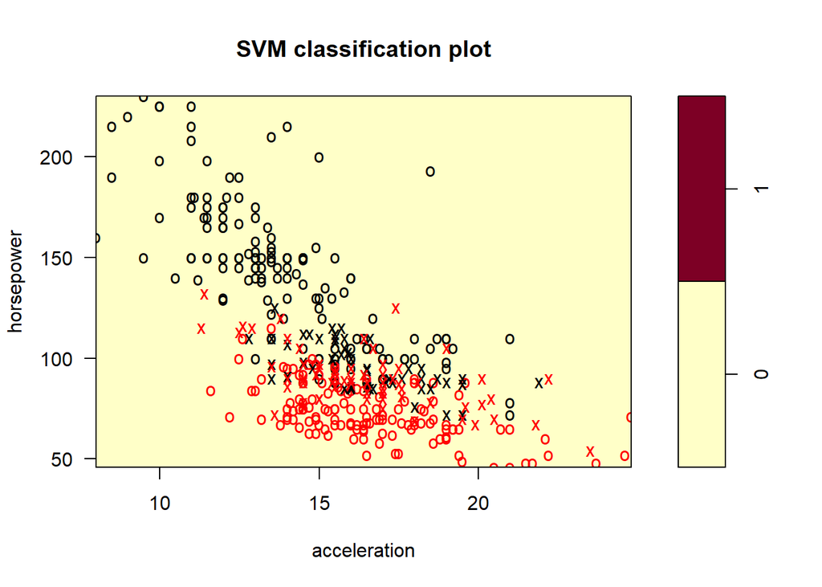

```r
plot(svm1_best, dat, horsepower~acceleration)
```

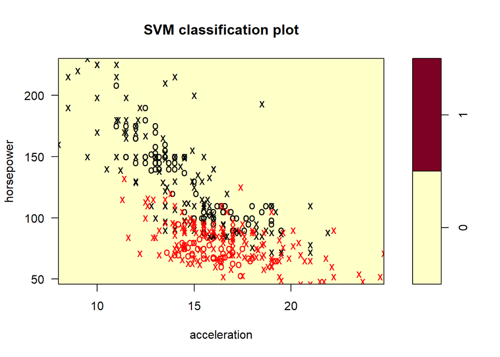

```r
plot(svm2_best, dat, horsepower~acceleration)
```

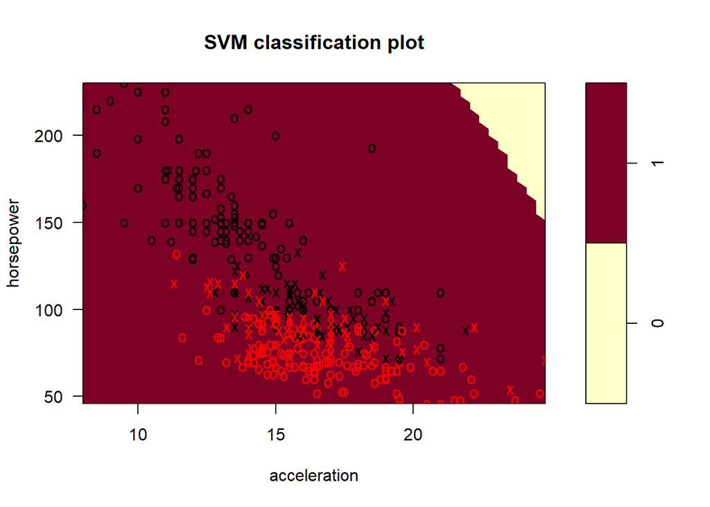

```r
plot(svm3_best, dat, horsepower~acceleration)
```

Shape “x” means the points is a support vector (wrong side of the margin), and “o” means it does not affect the model. Colors mean different classes. We can see that radial kernel has a lot more support vectors than linear kernel. Maybe this is the reason why it outperforms linear kernel. We can also see that the boundary for polynomial kernel does not fit the actual boundary.